# Bay of Fundy Scallop Assessment Script Workflow

Brittany Wilson

2021-05-18

# Overview

This document is intended as a guide to the inshore scallop assessment workflow and the R-scripts that are used in the assessment process. This document can be used as a Rmarkdown allowing the user to open the required scripts within Rstudio, or be read as a html or PDF document where the user can review the workflow and manually locate the scripts within the specified directory.

The Bay of Fundy assessment is separated by Scallop Production areas:

SPA1A, SPA1B, SPA3, SPA4 and SPA5, and SPA6

# Bay of Fundy

## 1. Standard Depth

- **Script Directory:**

  To be your forked Marscal Inshore repository path (e.g. C:/Users/WILSONB/Documents/GitHub/Inshore)
- **Purpose:**

  This script is used to pull bathymetry values from survey point locations and appends it to survey data (i.e. standardize depth values).
- **Output(s):**

  towsdd_StdDepth.csv, BoFMeanDepths.csv (derived from this depth data, does not change and will not need to be reproduced. Used in 7. Growth Rates (Growth)
- **Output Directory(s):**

  ESS:/Inshore/StandardDepth

**COMMIT CHANGES**

Ensure that all changes made to the script Standardize_depth.R have been saved and pushed to Marscal Inshore repository before continuing!

## 2. Meat Weight - Shell Height and Condition modeling (Growth)

- **Script Directory:**

  Y:/Inshore/BoF/2022/Assessment/Scripts/Growth (eventually to be our forked Marscal/inshore repository, e.g. C:/Users/WILSONB/Documents/GitHub/Inshore/BoF/Growth)
- **Purpose:**

  The MeatWeightShellHeight.R scripts models meat weight with shell height, depth and tow.
- **Overview:** Edits to model object YYYY will need to be made every assessment (e.g. MWTSHBF.YYYY)
1. Set up data for modelling:
   - Query detailed meat weight/shell height sampling data from database (scallsur.scwgthgt) for specified cruises (SPA1A1B4and5, SPA3, SPA6).
   - Query shell height bin data from database (scallsur.scliveres) for specified cruises (SPA1A1B4and5, SPA3, SPA6).
   - Format and merge depth information (from towsdd_StdDepth.csv) to the meat weight/shell height dataframe (BFdetail).
   - Format and merge depth information (from towsdd_StdDepth.csv) to the shell height bin data (BFlivefreq).
2. Run the Meat Weight Shell Height Model:
   - Subset for the survey year, shell height > 40mm
   - Centre Height and Depth values (e.g log height - mean(log height))
   - Run model (GLM) predicting meat weight as a function of fixed effects shell height and depth and random effect shell height grouped by tow.

**COMMIT CHANGES**

Ensure that all changes made to scripts MeatWeightShellHeight.R for each SPA have been saved and pushed to Marscal Inshore repository before continuing!

## 3. Spatial plots (Survey Indices)

- **Purpose:** Plot spatial patterns for Density, Biomass, Condition, Meat Count and Clapper data for the Full Bay of Fundy extent, SPA1A, 1B, 3, 4 and 5, and 6.
- **Script Directory:** To be your forked Marscal Inshore repository path (e.g. C:/Users/WILSONB/Documents/GitHub/Inshore/BoF/SurveyIndicies)
- **Output(s):**
  - Spatial plots for each area and commercial, recruit and pre-recruit size ranges
    - Density - ContPlot_SPA#_ComDensityYYYY.png, ContPlot_SPA#_RecDensityYYYY.png, ContPlot_SPA#_PreDensityYYYY.png
    - Biomass - ContPlot_SPA#_ComBiomassYYYY.png, ContPlot_SPA#_RecBiomassYYYY.png, ContPlot_SPA#_PreBiomassYYYY.png
    - Condition - ContPlot_SPA#_ConditionYYYY.png (using only commercial sizes)
    - Meat Count - ContPlot_SPA#_MeatcountYYYY.png (using only commercial sizes)
    - Clappers and Clapper proportion - ContPlot_SPA#_ComClappersYYYY.png, ContPlot_SPA#_RecClappersYYYY.png, ContPlot_SPA#_PropComClappersYYYY.png, ContPlot_SPA#_PropRecClappersYYYY.png
- **Output Directory(s):** Y:/Inshore/BoF/YYYY/Assessment/Figures

**COMMIT CHANGES**

Ensure that all changes made to BoFSpatialPlotsofSurveyData_pecjector.r have been saved and pushed to Marscal Inshore repository before continuing!

## 4. VonB (Growth)

- **Purpose:** These scripts model growth using the von-Bertalanffy growth equation for specified cruises (SPA1A1B4and5, SPA3, SPA6).

  **NOTE:** This script does not need to be run every year. New aging data is required for updated outputs.
- **Overview:**

Set up data for modelling: - Query detailed meat weight/shell height sampling data from database (scallsur.scwgthgt) for specified cruises (SPA1A1B4and5, SPA3, SPA6). - Format data for the model - Run the VonB

$L_t = L_\infty(1-e^{-K(t)})$

Where:

$L_t$ = Length at age $t$

$L_\infty$ = asymptotic length (length at which growth rate is zero) - estimated from the data

$K$ = Brody growth coeff (rate of growth towards asymptote) - estimated from the data

$t$ = scallop age (years)

- **Script Directory:** To be your forked Marscal Inshore repository path (e.g. C:/Users/WILSONB/Documents/GitHub/Inshore/BoF/Growth)
- **Output(s):**
- **Output Directory(s):**

**COMMIT CHANGES**

Ensure that all changes made to VonB.R scripts have been saved and pushed to Marscal Inshore repository before continuing!

## 5. Shell Height Frequencies (Growth)

- **Purpose:** This script produces plots of shell height frequencies for specified strata by year, and calculates commercial mean shell height in year t ($\bar{L}$) and uses parameters from the VonB growth model to predict how much a shell of height $L$ will grow in one year.

  **NOTE** - requires the script BoFstratadef.R (Inshore github repo) and PEDstrata package to run. **NOTE - TO DO: source the .RData files created by the vonB scripts (i.e. read in the outputs directly instead of hardcoding them in)**
- **Overview:**
- For each area (SPA1A, SPA1B, SPA3, SPA4 and SPA6) scripts are run separately.
  - Query shell height bin data from database (scallsur.scliveres) for specified Strata.
  - Calculate shell height frequency for each year by strata. **NOTE - Look into using sf to stratify**
  - Calculate stratified shell height frequency for all of area (SPA1A, SPA1B, SPA3, SPA4 and SPA6) by year
  - Plot shell height frequencies for each year (last 7 years)
  - Calculate $\bar{L}$ for all of area (SPA1A, SPA1B, SPA3, SPA4 and SPA6) by year for commercial and recruit sizes
  - Predict $\bar{L}$ in $t+1$:

  $\bar{L}_{t+1} = L_\infty * (1-e^{-e^{logK}}) + (e^{-e^{logK}}) * (\bar{L})$
  - Calculate $\bar{L}$ for each subarea for plotting
  - Repeat Tow plots (SPA1B - query from scallsur.sccomparisontows)

See Y:/Inshore/BoF/SurveyDesignTables/Areas for BoF Assessment modelling_Notes.docx for more details on substrata areas.

[figure not shown]

1. SPA1A:
   - 2 to 8 mile = Strata 6 and 7
   - 8 to 16 mile = Strata 12, 13, 14, 15, 16, 17, 18, 19, 20
   - Mid-Bay South = Strata 39
2. SPA1B:
   - Mid-Bay North = Strata 38 (Gets separated into East and West strata) **NOTE** Check east and west in script - The object names are reversed (i.e. West should be East)
   - Cape Spencer = Strata 37
   - Upper Bay 28C = Strata 53
   - Advocate Harbour = Strata 35
   - 28D Outer = Strata 49
   - Spencers Island = Strata 52
   - Scotts Bay = Strata 51

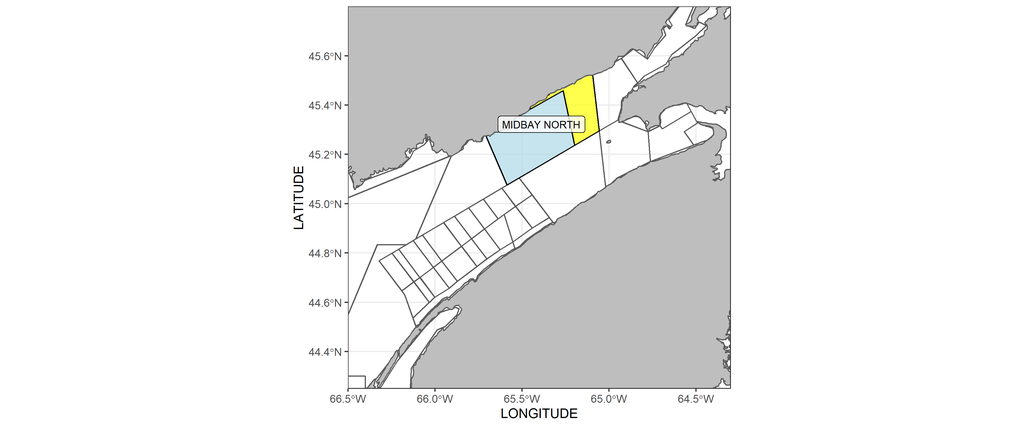

3. SPA3:
   - St. Mary’s Bay = Strata 22
   - Outside VMS strata = Strata 23, 24 (Brier Island, Lurcher)
   - Within VMS strata = Strata 99 (created using VMS strata shapefile - github)

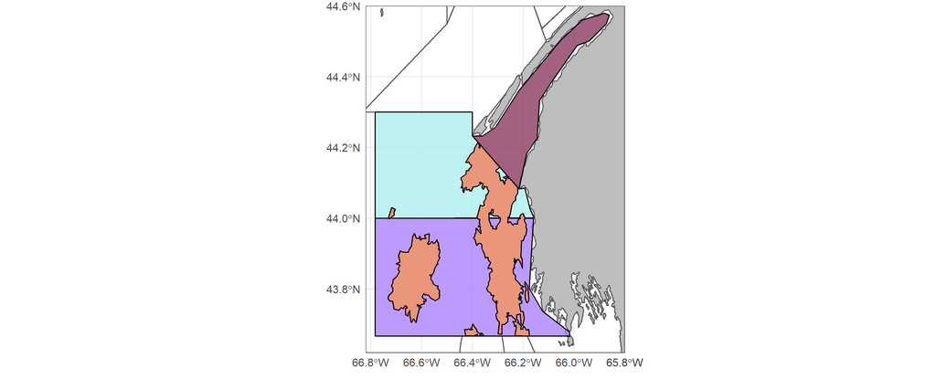

4. SPA4:
   - SPA4 (Modelled area) = Strata 1, 2, 3, 4, 5, 8, 9, 10
   - 0-2 mile = Strata 47
5. SPA6:
   - VMS IN STRATA
   - VMS OUT STRATA

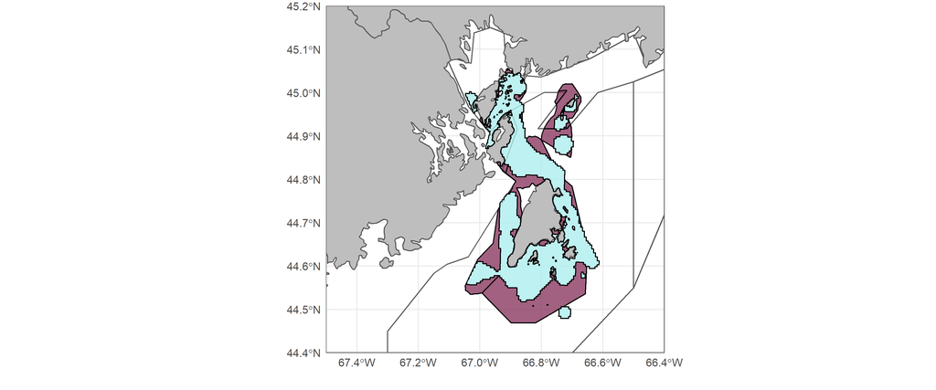

- **Script Directory:** To be your forked Marscal Inshore repository path (e.g. C:/Users/WILSONB/Documents/GitHub/Inshore/BoF/Growth)
- **Output(s):** - Shell Height Frequency plots for each year by strata
  - SPA1A
    - 2 to 8 mile - SPA1A_SHF_2to8.png
    - 8 to 16 mile - SPA1A_SHF_8to16.png
    - Mid-Bay South - SPA1A_SHF_MBS.png
    - All SPA1A Area - SPA1A_SHF_all.png
    - Plot of Commercial mean SH by year ($\bar{L}$) - SPA1A_lbar.png
    - Commercial mean SH by year ($\bar{L}$) - SPA1A.lbar.to.YYYY.csv & SPA1A.lbar.by.strata.YYYY.csv
    - Saved objects for predicting mean weight - SPA1A.YYYY.SHobj.R
  - SPA1B
    - Mid-Bay North - SPA1B_SHF_MBN.png
    - Cape Spencer - SPA1B_SHF_CS.png
    - Upper Bay 28C - SPA1B_SHF_28C.png
    - Advocate Harbour - SPA1B_SHF_AH.png
    - 28D Outer - SPA1B_SHF_Out.png
    - Spencers Island - SPA1B_SHF_SI.png
    - Scotts Bay - SPA1B_SHF_SB.png
    - All SPA1B Area - SPA1B_SHF_all.png
    - Repeated Tows - SPA1B_SHF_MBN_RepeatTows.png, SPA1B_SHF_AH_RepeatTows.png, SPA1B_SHF_28C_RepeatTows.png, SPA1B_SHF_Out_RepeatTows.png
    - Plot of Commercial mean SH by year ($\bar{L}$) - SPA1B_lbar.png
    - Commercial mean SH by year ($\bar{L}$) - SPA1B.lbar.to.YYYY.csv
    - Saved objects for predicting mean weight - SPA1B.YYYY.SHobj.R, SPA1BYYYY.lbarbyStrataGroup.R
  - SPA3
    - Inner VMS - SPA3_SHF_InVMS.png
    - Saint Mary’s Bay - SPA3_SHF_SMB.png
    - Outer VMS - SPA3_SHF_OutVMS.png
    - Modelled Area - SPA3_SHF_ModelledArea.png
    - Plot of Commercial mean SH by year ($\bar{L}$) - SPA3_lbar.png, SPA3_strata_lbar.png
    - Commercial mean SH by year ($\bar{L}$) - SPA3.SHF.modelled.area.means.to.YYYY.csv, SPA3.lbar.toYYYY.csv
    - Saved objects for predicting mean weight - SPA3.SHobj.YYYY.R
    - Repeat Tows - **NOTE** Needs to be updated to ggplot
  - SPA4
    - SPA4_SHF.png
    - SPA4_SHF_0to2mile.png
    - Plot of Commercial mean SH by year ($\bar{L}$) - SPA4_lbar.png
    - Commercial mean SH by year ($\bar{L}$) - SPA4.SHFmeans.toYYYY.csv, SPA4.lbar.toYYYY.csv
    - Saved objects for predicting mean weight - SPA4.SHobj.YYYY.R
  - SPA6
    - Inner VMS Strata - SPA6_SHF_InVMS.png
    - Outer VMS Strata - SPA6_SHF_OutVMS.png
    - Plot of Commercial mean SH by year ($\bar{L}$) - SPA6_lbar.png
    - Commercial mean SH by year ($\bar{L}$) - SPA6.lbar.by.strata.YYYY.csv
    - Saved objects for predicting mean weight - SPA6.SHobj.IN.YYYY.R, SPA6.SHobj.OUT.YYYY.R
- **Output Directory(s):**
  - Y:/Inshore/BoF/Figures (.png)
  - Y:/Inshore/BoF/Assessment/Data/SurveyIndices/AREA (.csv)

**COMMIT CHANGES**

Ensure that all changes made to SHF.R scripts have been saved and pushed to Marscal Inshore repository before continuing!

## 6. SPA5 Numbers Weight per Tow, SHF and Clappers

- **Purpose:** Calculates numbers per tow and weight per tow, plots shell height frequency, clappers per tow, clapper shell height frequency.
- **Overview:**
  - Calculates numbers per tow and weight per tow using simple mean.
  - Calculates weights per tow and weight per tow using simple mean
  - Calculates numbers of clappers per tow and weight per tow using simple mean.
- **Script Directory:** To be your forked Marscal Inshore repository path (e.g. C:/Users/WILSONB/Documents/GitHub/Inshore/BoF/SurveyIndices)
- **Output(s):**
  - SPA5.Index.NumbersYYYY.csv
  - SPA5.Index.WeightYYYY.csv
  - SPA5_NumberWeightPerTowYYYY.png
  - SPA5_SHF_YYYY.png
  - Clappers - SPA5.Index.ClappersYYYY.csv
  - SPA5_ClappersPerTowYYYY.png
  - SPA5_dead_SHF_YYYY.png
- **Output Directory(s):**
  - Y:/Inshore/BoF/Figures (.png)
  - Y:/Inshore/BoF/Assessment/Data/SurveyIndices/SPA1A1B4and5 (.csv)

## 7. Growth Rates (Growth)

- **Purpose:** Saves Predicted and Actual growth rates for commercial ($g$) and recruit ($gR$) sized scallops.

**NOTE:** This script requires inputs from 2. Meat Weight - Shell Height and Condition modeling (Growth) and 5. Shell Height Frequencies (Growth)

- **Overview:**
  - Import outputs from previous scripts in respective areas (SPA1A, SPA1B, SPA3, SPA4and5, and SPA6) e.g. AREAgrowth2019.RData, AREA2019.SHobj.R, AREA.ActualGrowthRateObj.YYYY.R, AREAPredictedGrowthRateObj.YYYY.R
  - Imports predicted and actual shell height, MWSH.YYYY model, and meat weight shell height data from samples.

    **Actual Growth Rates**
  - commercial mean meat weight in year t-1 is predicted using predicted SH (SH predicted from year t-1 to year t) and actual mw/sh relationship in year t
  - recruit mean meat weight in year t-1 is predicted using predicted SH (SH predicted from year t-1 to year t) and actual mw/sh relationship in year t
  - actual commercial mean meat weight in year t is predicted and
  - actual recruit mean meat weight in year t is predicted.

    **Predicted Growth Rates**
  - Calculate mean weight of commercial and recruit animals:

    1. In year t (“actual”) using mean SH in year t and meat weight shell height relationship in year t

    2. In year t+1 (“pred”) using predicted mean SH in year t+1 (predicted from year t) and meat weight shell height relationship in year t
  - i.e. predicted g and gR were from year t to t+1, assuming it is unknown.

  $g_{t-1} = \bar{w_t}/\bar{w}_{t-1}$
- **Script Directory:** To be your forked Marscal Inshore repository path (e.g. C:/Users/WILSONB/Documents/GitHub/Inshore/BoF/Growth)
- **Output(s):**
  - SPA1A
    - spa1A.growthrate.YYYY.csv
    - SPA1A_GrowthRate_ComRec_Actual.png
    - SPA1A_GrowthRate_Com_ActualPredicted.png
    - SPA1A_GrowthRate_Rec_ActualPredicted.png
  - SPA1B
    - spa1B.growthrate.YYYY.csv
    - SPA1B_GrowthRate_ComRec_Actual.png
    - SPA1B_GrowthRate_Com_ActualPredicted.png
    - SPA1B_GrowthRate_Rec_ActualPredicted.png
  - SPA3
    - spa3.growthrate.YYYY.csv
    - SPA3_GrowthRate_ComRec_Actual.png
    - SPA3_GrowthRate_Com_ActualPredicted.png
    - SPA3_GrowthRate_Rec_ActualPredicted.png
  - SPA4
    - spa4.growthrate.YYYY.csv
    - SPA4_GrowthRate_ComRec_Actual.png
    - SPA4_GrowthRate_Com_ActualPredicted.png
    - SPA4_GrowthRate_Rec_ActualPredicted.png
  - SPA6
    - spa6.growthrate.YYYY.csv
    - SPA6_GrowthRate_ComRec_Actual.png
    - SPA6_GrowthRate_Com_ActualPredicted.png
    - SPA6_GrowthRate_Rec_ActualPredicted.png
- **Output Directory(s):**
  - Y:/Inshore/BoF/Figures (.png)
  - Y:/Inshore/BoF/Assessment/Data/Growth/AREA (.csv)

**COMMIT CHANGES**

Ensure that all changes made to GrowthRates_AREA.R scripts have been saved and pushed to Marscal Inshore repository before continuing!

## 8. Number Weights per Tow (Survey Indices)

- **Purpose:** Calculates population numbers (numbers scaled to total area) and biomass indices.

**NOTE:** This script requires inputs from 2. Meat Weight - Shell Height and Condition modeling (Growth) (AREAliveweightYYYY.csv) and data from Scallsur database (scliveres and sccomparisontows).

- **Overview:**
  - Checks for potential errors that will break the SPR estimates (i.e. miss-matches in StrataIDs, or if one repeat has 0s recorded for recruit or commercial sizes), and correct for any errors from previous years.
  - Calculates numbers per tow and population numbers for Recruit and Commercial size scallops:
    - Runs simple means and SPR for each area.
  - Calculates weights per tow and population biomass for Recruit and Commercial size scallops:
    - Runs simple means and SPR for each area.
- **Script Directory:** To be your forked Marscal Inshore repository path (e.g. C:/Users/WILSONB/Documents/GitHub/Inshore/BoF/SurveyIndices)
- **Output(s):**
  - AREA.Index.Numbers.YYYY.csv - contains $Npt$, $N$
  - AREA.Index.WeightYYYY.csv - contains $I$, $IR$, $Icv$, $IRcv$
  - AREA_NumberpertowYYYY.png
  - AREA_WeightpertowYYYY.png
- **Output Directory(s):**
  - Y:/Inshore/BoF/Figures (.png)
  - Y:/Inshore/BoF/Assessment/Data/Growth/AREA (.csv)

**COMMIT CHANGES**

Ensure that all changes made to AREA_NumbersWeightperTow_YYYY.r scripts have been saved and pushed to Marscal Inshore repository before continuing!

## 9. Clappers (Survey Indices)

- **Purpose:**
  - Calculates clapper numbers per tow, clapper population numbers and clapper shell height frequencies
- **Overview:**
  - Clapper numbers per tow clapper population numbers for commercial and recruit sizes are calculated using simple means.
  - plots shell height frequencies for clappers for each area
- **Script Directory:** To be your forked Marscal Inshore repository path (e.g. C:/Users/WILSONB/Documents/GitHub/Inshore/BoF/SurveyIndices)

  **NOTE** Drop the ‘s’ in file name for SPA3 and 4 OR add them for the others for consistency
- **Output(s):**
  - AREA.Index.Clappers.YYYY.csv
  - AREA.Clappers.N.formodel.YYYY.csv
  - AREA_clapper_NumberpertowYYYY.png
  - AREA_clapper_SHF.png (1 for each for each substrata)
- **Output Directory(s):**
  - Y:/Inshore/BoF/Figures (.png)
  - Y:/Inshore/BoF/Assessment/Data/Growth/AREA (.csv)

**COMMIT CHANGES**

Ensure that all changes made to Clapper_AREA.r scripts have been saved and pushed to Marscal Inshore repository before continuing!

## 10. Ratio Lined-Unlined (Survey Indices)

- **Purpose:** Calculates ratio of unlined and lined numbers per tow.

**NOTE:** This script requires inputs from Scallsur database (sclinedlive_std, scunlinedlive_std and sccomparisontows).

- **Overview:**
  - Errors that will break the SPR estimates (i.e. miss-matches in StrataIDs, or if one repeat has 0s recorded for recruit or commercial sizes) are corrected.
  - Calculates estimates for lined gear (scaled to total area) for commercial size scallops for each year in each area
    - Runs simple means and SPR.
  - Calculates estimates for unlined gear (scaled to total area) for commercial size scallops for each year in each area
    - Runs simple means and SPR.
  - Calculates ratio of lined and unlined estimates (mean numbers per tow).
  - Plots time series Lined and Unlined mean numbers per tow.
- **Script Directory:** To be your forked Marscal Inshore repository path (e.g. C:/Users/WILSONB/Documents/GitHub/Inshore/BoF/SurveyIndices)
- **Output(s):**
  - AREA_lined.vs.unlinedYYYY.png
  - AREA_ratioYYYY.png
  - AREA_ratioLinedtoUnlinedYYYY.csv
- **Output Directory(s):**
  - Y:/Inshore/BoF/Figures (.png)
  - Y:/Inshore/BoF/Assessment/Data/SurveyIndices/AREA (.csv)

**COMMIT CHANGES**

Ensure that all changes made to AREA_RatioLinedUnlined_YYYY.r scripts have been saved and pushed to Marscal Inshore repository before continuing!

## 11. Model (Model)

- **Purpose:**
  - Population model - Bayesian state space model

    $B_{t+1} = (e^{-m_t}g_t(B_t-C_t)+e^{-m_t}g_{Rt}R_t)\tau_t$
- **Overview:**
  - Model formulation for BoF: have biomass remove catch then grow up and kill off.
  - Starts by creating comparison file (SPAx_ModelData_R.xlsx). Ensure previous years data has not changed. Investigate if differences are flagged.
  - Import data from generated SPAx_ModelData_R_YYYY-MM-DD.xlsx :
    - C - Catch
    - N - population numbers
    - I - Biomass scaled to full area
    - I.cv -
    - IR - Recruit Biomass scaled to full area
    - IR.cv -
    - ratiolined - ratio of lined to unlined
    - g - Commercial growth
    - gR - recruit growth
    - clappers - clapper numbers
  - Set parameters to be returned from the winbugs model run:
    - B - Commercial Biomass (in tonnes)
    - R - Recruit Biomass (in tonnes)
    - q - Catchability
    - K - Scaling parameter
    - P - Biomass scaled by K
    - **sigma**
    - S - dissolution factor (factors into the clapper model)
    - m - mortality
    - **kappa.tau - observation error for clappers?**
    - r - recruit biomass scaled by K
    - Fmort - instant mortality
    - mu - exploitation rate
    - Irep - Commercial Biomass not scaled by q
    - IRrep - Recruit Biomass not scaled by q
    - Presid, sPresid, Iresid, IRresid, sIresid, sIRresid - residuals
  - Model is run in Winbugs and diagnostics are run (i.e. checks for model convergence)
  - Plots of time series of survey biomass estimates are made
  - Plots biomass time series (EN/FR), box plot contains 80% of the data when pred.lim = 0.2 (i.e. 80% of the data is located between the whiskers)
  - Plot of the posteriors
  - Plots of residuals
  - Plot of the predicted prediction-evaluation
  - Creates decision table and saves out model summary.
- **Script Directory:** To be your forked Marscal Inshore repository path (e.g. C:/Users/WILSONB/Documents/GitHub/Inshore/BoF/Model)
- **Output(s):**
  - SPAx_ModelData_R.xlsx
  - SPAx_Model_YYYY.RData
  - spaXModelOutput.csv
  - Survey_est_figure_AREA.png
  - Model_biomass_figure_AREA.png
  - plot.Presids_AREA.png, plot.sPresid_AREA.png, plot.Iresid_AREA.png. plot.IRresid_Area.png
  - Prediction_evaluation_figure_predicted_AREA.png
  - Prediction_evaluation_figure_actual_AREA.png
  - decisiontableYYYY_AREA.csv
  - SPA6_Model_YYYY.RData
  - Model_results_and_diagnostics_YYYY_AREA.RData
- **Output Directory(s):**
  - Y:/Inshore/BoF/Model/AREA

**COMMIT CHANGES**

Ensure that all changes made to Model scripts have been saved and pushed to Marscal Inshore repository before continuing!